# pm566hw1

Changqing Su

2020/9/8

# 1.

### read tables

```r
y2004=data.table::fread("y2004.csv")
y2019=data.table::fread("y2019.csv")
```

### checking data

For year 2004

```r
dim(y2004)
```

```
## [1] 19233    20
```

```r
head(y2004)
```

```
##          Date Source  Site ID POC Daily Mean PM2.5 Concentration    UNITS
## 1: 01/01/2004    AQS 60010007   1                            8.9 ug/m3 LC
## 2: 01/02/2004    AQS 60010007   1                           12.2 ug/m3 LC
## 3: 01/03/2004    AQS 60010007   1                           16.5 ug/m3 LC
## 4: 01/04/2004    AQS 60010007   1                           18.1 ug/m3 LC
## 5: 01/05/2004    AQS 60010007   1                           11.5 ug/m3 LC
## 6: 01/06/2004    AQS 60010007   1                           32.5 ug/m3 LC
##    DAILY_AQI_VALUE Site Name DAILY_OBS_COUNT PERCENT_COMPLETE
## 1:              37 Livermore               1              100
## 2:              51 Livermore               1              100
## 3:              60 Livermore               1              100
## 4:              64 Livermore               1              100
## 5:              48 Livermore               1              100
## 6:              94 Livermore               1              100
##    AQS_PARAMETER_CODE                     AQS_PARAMETER_DESC CBSA_CODE
```

[output cut: 20 more lines]

```r
tail(y2004)
```

```
##          Date Source  Site ID POC Daily Mean PM2.5 Concentration    UNITS
## 1: 12/14/2004    AQS 61131003   1                             11 ug/m3 LC
## 2: 12/17/2004    AQS 61131003   1                             16 ug/m3 LC
## 3: 12/20/2004    AQS 61131003   1                             17 ug/m3 LC
## 4: 12/23/2004    AQS 61131003   1                              9 ug/m3 LC
## 5: 12/26/2004    AQS 61131003   1                             24 ug/m3 LC
## 6: 12/29/2004    AQS 61131003   1                              9 ug/m3 LC
##    DAILY_AQI_VALUE            Site Name DAILY_OBS_COUNT PERCENT_COMPLETE
## 1:              46 Woodland-Gibson Road               1              100
## 2:              59 Woodland-Gibson Road               1              100
## 3:              61 Woodland-Gibson Road               1              100
## 4:              38 Woodland-Gibson Road               1              100
## 5:              76 Woodland-Gibson Road               1              100
## 6:              38 Woodland-Gibson Road               1              100
##    AQS_PARAMETER_CODE       AQS_PARAMETER_DESC CBSA_CODE
```

[output cut: 20 more lines]

```r
str(y2004)
```

```
## Classes 'data.table' and 'data.frame':   19233 obs. of  20 variables:
##  $ Date                          : chr  "01/01/2004" "01/02/2004" "01/03/2004" "01/04/2004" ...
##  $ Source                        : chr  "AQS" "AQS" "AQS" "AQS" ...
##  $ Site ID                       : int  60010007 60010007 60010007 60010007 60010007 60010007 60010007 60010007 60010007 60010007 ...
##  $ POC                           : int  1 1 1 1 1 1 1 1 1 1 ...
##  $ Daily Mean PM2.5 Concentration: num  8.9 12.2 16.5 18.1 11.5 32.5 14 29.9 21 15.7 ...
##  $ UNITS                         : chr  "ug/m3 LC" "ug/m3 LC" "ug/m3 LC" "ug/m3 LC" ...
##  $ DAILY_AQI_VALUE               : int  37 51 60 64 48 94 55 88 70 59 ...
##  $ Site Name                     : chr  "Livermore" "Livermore" "Livermore" "Livermore" ...
##  $ DAILY_OBS_COUNT               : int  1 1 1 1 1 1 1 1 1 1 ...
##  $ PERCENT_COMPLETE              : num  100 100 100 100 100 100 100 100 100 100 ...
##  $ AQS_PARAMETER_CODE            : int  88101 88502 88502 88101 88502 88502 88101 88502 88502 88101 ...
##  $ AQS_PARAMETER_DESC            : chr  "PM2.5 - Local Conditions" "Acceptable PM2.5 AQI & Speciation Mass" "Acceptable PM2.5 AQI & Speciation Mass" "PM2.5 - Local Conditions" ...
##  $ CBSA_CODE                     : int  41860 41860 41860 41860 41860 41860 41860 41860 41860 41860 ...
##  $ CBSA_NAME                     : chr  "San Francisco-Oakland-Hayward, CA" "San Francisco-Oakland-Hayward, CA" "San Francisco-Oakland-Hayward, CA" "San Francisco-Oakland-Hayward, CA" ...
##  $ STATE_CODE                    : int  6 6 6 6 6 6 6 6 6 6 ...
##  $ STATE                         : chr  "California" "California" "California" "California" ...
##  $ COUNTY_CODE                   : int  1 1 1 1 1 1 1 1 1 1 ...
##  $ COUNTY                        : chr  "Alameda" "Alameda" "Alameda" "Alameda" ...
##  $ SITE_LATITUDE                 : num  37.7 37.7 37.7 37.7 37.7 ...
##  $ SITE_LONGITUDE                : num  -122 -122 -122 -122 -122 ...
##  - attr(*, ".internal.selfref")=<externalptr>
```

For year 2019

```r
dim(y2019)
```

```
## [1] 53328    20
```

```r
head(y2019)
```

```
##          Date Source  Site ID POC Daily Mean PM2.5 Concentration    UNITS
## 1: 01/01/2019    AQS 60010007   3                            5.7 ug/m3 LC
## 2: 01/02/2019    AQS 60010007   3                           11.9 ug/m3 LC
## 3: 01/03/2019    AQS 60010007   3                           20.1 ug/m3 LC
## 4: 01/04/2019    AQS 60010007   3                           28.8 ug/m3 LC
## 5: 01/05/2019    AQS 60010007   3                           11.2 ug/m3 LC
## 6: 01/06/2019    AQS 60010007   3                            2.7 ug/m3 LC
##    DAILY_AQI_VALUE Site Name DAILY_OBS_COUNT PERCENT_COMPLETE
## 1:              24 Livermore               1              100
## 2:              50 Livermore               1              100
## 3:              68 Livermore               1              100
## 4:              86 Livermore               1              100
## 5:              47 Livermore               1              100
## 6:              11 Livermore               1              100
##    AQS_PARAMETER_CODE       AQS_PARAMETER_DESC CBSA_CODE
```

[output cut: 20 more lines]

```r
tail(y2019)
```

```
##          Date Source  Site ID POC Daily Mean PM2.5 Concentration    UNITS
## 1: 11/11/2019    AQS 61131003   1                           13.5 ug/m3 LC
## 2: 11/17/2019    AQS 61131003   1                           18.1 ug/m3 LC
## 3: 11/29/2019    AQS 61131003   1                           12.5 ug/m3 LC
## 4: 12/17/2019    AQS 61131003   1                           23.8 ug/m3 LC
## 5: 12/23/2019    AQS 61131003   1                            1.0 ug/m3 LC
## 6: 12/29/2019    AQS 61131003   1                            9.1 ug/m3 LC
##    DAILY_AQI_VALUE            Site Name DAILY_OBS_COUNT PERCENT_COMPLETE
## 1:              54 Woodland-Gibson Road               1              100
## 2:              64 Woodland-Gibson Road               1              100
## 3:              52 Woodland-Gibson Road               1              100
## 4:              76 Woodland-Gibson Road               1              100
## 5:               4 Woodland-Gibson Road               1              100
## 6:              38 Woodland-Gibson Road               1              100
##    AQS_PARAMETER_CODE       AQS_PARAMETER_DESC CBSA_CODE
```

[output cut: 20 more lines]

```r
str(y2019)
```

```
## Classes 'data.table' and 'data.frame':   53328 obs. of  20 variables:
##  $ Date                          : chr  "01/01/2019" "01/02/2019" "01/03/2019" "01/04/2019" ...
##  $ Source                        : chr  "AQS" "AQS" "AQS" "AQS" ...
##  $ Site ID                       : int  60010007 60010007 60010007 60010007 60010007 60010007 60010007 60010007 60010007 60010007 ...
##  $ POC                           : int  3 3 3 3 3 3 3 3 3 3 ...
##  $ Daily Mean PM2.5 Concentration: num  5.7 11.9 20.1 28.8 11.2 2.7 2.8 7 3.1 7.1 ...
##  $ UNITS                         : chr  "ug/m3 LC" "ug/m3 LC" "ug/m3 LC" "ug/m3 LC" ...
##  $ DAILY_AQI_VALUE               : int  24 50 68 86 47 11 12 29 13 30 ...
##  $ Site Name                     : chr  "Livermore" "Livermore" "Livermore" "Livermore" ...
##  $ DAILY_OBS_COUNT               : int  1 1 1 1 1 1 1 1 1 1 ...
##  $ PERCENT_COMPLETE              : num  100 100 100 100 100 100 100 100 100 100 ...
##  $ AQS_PARAMETER_CODE            : int  88101 88101 88101 88101 88101 88101 88101 88101 88101 88101 ...
##  $ AQS_PARAMETER_DESC            : chr  "PM2.5 - Local Conditions" "PM2.5 - Local Conditions" "PM2.5 - Local Conditions" "PM2.5 - Local Conditions" ...
##  $ CBSA_CODE                     : int  41860 41860 41860 41860 41860 41860 41860 41860 41860 41860 ...
##  $ CBSA_NAME                     : chr  "San Francisco-Oakland-Hayward, CA" "San Francisco-Oakland-Hayward, CA" "San Francisco-Oakland-Hayward, CA" "San Francisco-Oakland-Hayward, CA" ...
##  $ STATE_CODE                    : int  6 6 6 6 6 6 6 6 6 6 ...
##  $ STATE                         : chr  "California" "California" "California" "California" ...
##  $ COUNTY_CODE                   : int  1 1 1 1 1 1 1 1 1 1 ...
##  $ COUNTY                        : chr  "Alameda" "Alameda" "Alameda" "Alameda" ...
##  $ SITE_LATITUDE                 : num  37.7 37.7 37.7 37.7 37.7 ...
##  $ SITE_LONGITUDE                : num  -122 -122 -122 -122 -122 ...
##  - attr(*, ".internal.selfref")=<externalptr>
```

### checking key variables

```r
range(y2004$`Daily Mean PM2.5 Concentration`)
```

```
## [1]  -0.1 251.0
```

```r
table(y2004$STATE)
```

```
##
## California
##      19233
```

```r
table(y2004$COUNTY)
```

```
##
##         Alameda           Butte       Calaveras          Colusa    Contra Costa
##             458             444              61             201             259
##       Del Norte       El Dorado          Fresno        Humboldt        Imperial
##             117             128             811              58             366
##            Inyo            Kern           Kings            Lake     Los Angeles
##             247            1304              84              60            2243
##           Marin        Mariposa       Mendocino          Merced            Mono
##             120             320              61              90             181
##        Monterey          Nevada          Orange          Placer          Plumas
##              60             232             529             246             258
##       Riverside      Sacramento      San Benito  San Bernardino       San Diego
##            1203            1453             122             893            1431
##   San Francisco     San Joaquin San Luis Obispo       San Mateo   Santa Barbara
##             560             122             176             354             225
##     Santa Clara      Santa Cruz          Shasta        Siskiyou          Solano
##             660              56             181             117             361
##          Sonoma      Stanislaus          Sutter         Trinity          Tulare
##              92             183             309             115             627
##         Ventura            Yolo
##             580             475
```

```r
table(y2004$SITE_LATITUDE)
```

```
##
## 32.6312420008573         32.67618     32.709223612 32.7252260005939
##              113              162              337               23
## 32.7911940008595         32.79222 32.8364610008601         32.97833
##              438              105              108               99
##  33.127769000864 33.4636438345227         33.63003         33.70853
##              412              109              111              161
##         33.79236         33.82376         33.83062         33.85275
##              327              325              418              112
##         33.92899         33.94603 33.9995800008751         34.01407
##              115              110              711              108
##      34.03723364 34.0665900008759         34.06957         34.10002
##              112              535              121              199
## 34.1066780008763          34.1326          34.1365         34.17605
##              106              113              279              109
## 34.1939253249244         34.19925        34.210169         34.25239
##              121              106              180              117
## 34.2646400008783        34.276316        34.404281 34.4277749961254
##               52              172              111               55
## 34.5109611108812 34.6697390008831  34.733888868675     34.813034257
##              182              111              112              115
##     34.828839434        34.942872 35.0505513494936      35.28386358
##              107               58               63               59
##        35.324636        35.356615        35.385574         35.49158
##              100              850               88              117
##         35.62109        36.102244 36.3321793109462         36.48324
##               96               84              515              122
##        36.487823     36.498834948        36.508611 36.6942610009043
##              128              112              119               60
##         36.72639 36.7813328518401        36.819449  36.983320000907
##               90              521               90               56
## 37.2206398607598          37.3062         37.30832        37.348497
##              110              213               90              447
##        37.482934        37.535833        37.642165         37.64571
##              354               94              183               59
##        37.687526         37.71325          37.7338        37.748707
##              364              110              197              210
##        37.765946        37.936013 37.9507408985318 38.0880230383045
##              363              259              122              122
##        38.102507     38.122978522         38.20185        38.443503
##              361              120               61               92
##         38.53445        38.556326         38.56844 38.6137790009202
##              359              233              806              414
##         38.66121         38.74643        38.944979 38.9759996246692
##              116              246                9              119
##          39.0327 39.1387725442464         39.15047         39.18919
##               60              309               61              201
## 39.2334770009245        39.327563 39.3278300009251  39.757371488392
##               56              322              176              122
##        39.808333 39.9395670009288         40.53999  40.550130000932
##              181               77              110               58
##          40.6304         40.69184 40.7862473556073         40.80178
##                6                7              115               58
##     41.560952388     41.711824509
##              117              117
```

```r
table(y2004$SITE_LONGITUDE)
```

```
##
##         -124.1621    -124.083964246        -123.20655        -122.92229
##                58               117                61                60
##    -122.909439692 -122.805706652049       -122.710169         -122.4031
##               120               115                92                 6
##        -122.40179       -122.399044         -122.3824        -122.38092
##                 7               363               197                58
##       -122.237976        -122.20337       -122.026154        -121.99887
##               361               354               259               201
##        -121.98822       -121.961823       -121.894898        -121.84885
##                56                94               447               213
## -121.843286344899       -121.784217         -121.7734        -121.73269
##               122               364               359               116
##       -121.668811       -121.623271 -121.618548986224        -121.57646
##               322                60               309               110
##     -121.50999312        -121.49311       -121.458499       -121.368014
##               117               806               233               414
## -121.268522670981        -121.26498        -121.15688       -121.055608
##               122               246               122                56
##       -120.994212       -120.944376       -120.680277        -120.66804
##               183                77                61               117
##    -120.655171313       -120.480456       -120.471667       -120.435611
##                59                90               181                58
##       -120.184592 -120.103505924399  -120.00834936928       -119.970609
##               176               119               112                 9
##  -119.77318981409          -119.733       -119.716433         -119.7062
##               521                90                90               110
## -119.691217778642       -119.587094        -119.56565 -119.291227556039
##                55               210                84               515
## -119.178068761591 -119.155556956851       -119.143182       -119.062613
##               122               110               117               850
##       -119.015009       -118.997627        -118.96652    -118.884819458
##                88               100                59               115
##    -118.880056442       -118.870509    -118.824821113        -118.80998
##               107               180               112               111
##       -118.683685        -118.53276        -118.31712        -118.22688
##               172               106               109               535
##        -118.21071        -118.18921        -118.17533 -118.147293620967
##               115               325               327                63
##       -118.130511         -118.1272        -118.06056        -117.93845
##               111               113               108               418
##        -117.92391       -117.871036    -117.690888554        -117.67593
##               279               128               112               111
##        -117.67296        -117.49201        -117.41601        -117.40063
##                96               199               711               110
##        -117.32554       -117.274063    -117.154841053       -117.128752
##               182               106               337               108
##       -117.075086       -117.059088 -116.971457297006       -116.942092
##               412               113               109               438
## -116.914063106369        -116.86147       -116.847778        -116.54101
##               121                52               119               112
##        -116.38893 -116.365203426694        -116.21537        -115.56306
##               121                23               161               105
##        -115.53917        -115.48307
##                99               162
```

The data seems good. Only one thing seems not reasonable is that some values of PM2.5 concentration are negative. This may be because a constant error value was subtracted when computing the PM2.5 value. We can either leave them there or set them to 0.

# 2.

```r
#add year column and bind the two years
y2004$year=2004
y2019$year=2019
pmdata=rbind(y2004,y2019)

#rename column names
names(pmdata)[5]="PM2.5"
names(pmdata)[19]="lat"
names(pmdata)[20]="lon"
```

# 3.

```r
# Firstly, pull out the unique locations for two years.
location04=y2004[!duplicated(y2004[,"Site ID"])]
location19=y2019[!duplicated(y2019[,"Site ID"])]
pmlocation=rbind(location04,location19)
names(pmlocation)[5]="PM2.5"
names(pmlocation)[19]="lat"
names(pmlocation)[20]="lon"

# create the map.
library(leaflet)
leaflet(pmlocation) %>%
  addProviderTiles('OpenStreetMap') %>%
    addCircles(lat=~lat,lng=~lon,  fillOpacity=0.6, radius=100,color= ~ifelse(year==2004,'red','deepskyblue'))
```

[interactive chart not shown]

The red circles are sites in 2004. The light blue circles are sites in 2019. And the dark blue circles are sites exist in both years. According to the map, the number of sites increased a lot from 2004 to 2019. Most of the newly built sites are located near the ocean, particularly Sacramento, San Jose,and Los Angeles.

# 4.

```r
pmdata[which(is.null(pmdata[,PM2.5]))]
```

```
## Empty data.table (0 rows and 21 cols): Date,Source,Site ID,POC,PM2.5,UNITS...
```

```r
range(pmdata$PM2.5)
```

```
## [1]  -2.2 251.0
```

```r
pmdata[which(pmdata[,PM2.5]>150)]
```

```
##          Date Source  Site ID POC PM2.5    UNITS DAILY_AQI_VALUE
## 1: 07/18/2004    AQS 60431001   3 251.0 ug/m3 LC             301
## 2: 07/19/2004    AQS 60431001   3 170.4 ug/m3 LC             221
##                                     Site Name DAILY_OBS_COUNT PERCENT_COMPLETE
## 1: Yosemite NP-Yosemite Village Vistor Center               1              100
## 2: Yosemite NP-Yosemite Village Vistor Center               1              100
##    AQS_PARAMETER_CODE                     AQS_PARAMETER_DESC CBSA_CODE
## 1:              88502 Acceptable PM2.5 AQI & Speciation Mass        NA
## 2:              88502 Acceptable PM2.5 AQI & Speciation Mass        NA
##    CBSA_NAME STATE_CODE      STATE COUNTY_CODE   COUNTY      lat       lon year
## 1:                    6 California          43 Mariposa 37.74871 -119.5871 2004
## 2:                    6 California          43 Mariposa 37.74871 -119.5871 2004
```

```r
pmdata[which(pmdata[,PM2.5]<0)]
```

```
##            Date Source  Site ID POC PM2.5    UNITS DAILY_AQI_VALUE
##   1: 12/08/2004    AQS 60199000   1  -0.1 ug/m3 LC               0
##   2: 12/01/2019    AQS 60010011   3  -0.3 ug/m3 LC               0
##   3: 12/01/2019    AQS 60010012   3  -0.5 ug/m3 LC               0
##   4: 02/03/2019    AQS 60070008   3  -0.3 ug/m3 LC               0
##   5: 02/17/2019    AQS 60070008   3  -0.1 ug/m3 LC               0
##  ---
## 289: 01/07/2019    AQS 61110009   3  -0.1 ug/m3 LC               0
## 290: 01/08/2019    AQS 61110009   3  -0.5 ug/m3 LC               0
## 291: 12/26/2019    AQS 61110009   3  -0.5 ug/m3 LC               0
## 292: 01/26/2019    AQS 61112002   3  -0.4 ug/m3 LC               0
## 293: 12/26/2019    AQS 61113001   3  -0.4 ug/m3 LC               0
##                       Site Name DAILY_OBS_COUNT PERCENT_COMPLETE
##   1:          Kaiser Wilderness               1              100
##   2:               Oakland West               1              100
```

[output cut: 45 more lines]

There is no missing value in the dataset.

Since PM2.5 is considered very unhealthy when it is above 150, extract the data using PM2.5 >150. 2 observations are both located in Yosemite national park. It may caused by the Yosemite wildfire.

Since PM2.5 should not be less than 0, extract the data using PM2.5 <0. 293 observations are mostly located at the beach. The air quality is generally good near the ocean, and the results may subtract by a standard error value. So, it appears negative.

# 5.

For state level

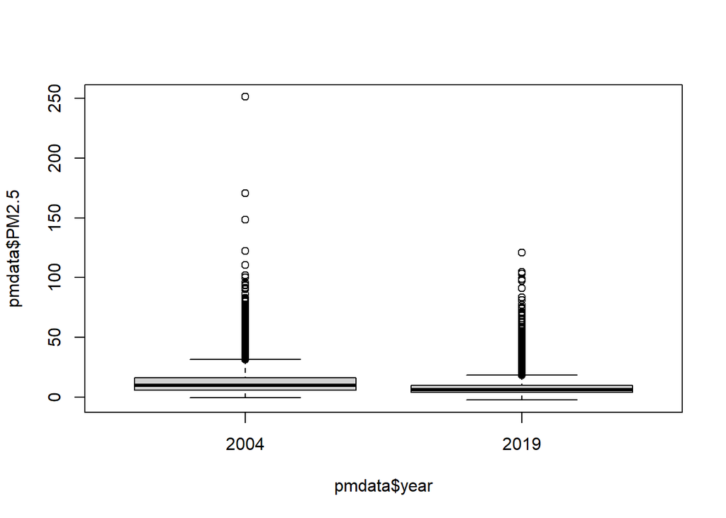

```r
boxplot(pmdata$PM2.5~pmdata$year)
```

The boxplot shows that overall, the year of 2004 has higher average PM2.5 concentration than year of 2019 with a larger range. One reason could be that there were more air pollution in 2004. One another reason could be newly built sites are close to the ocean and they have better air conditions.

For LA county

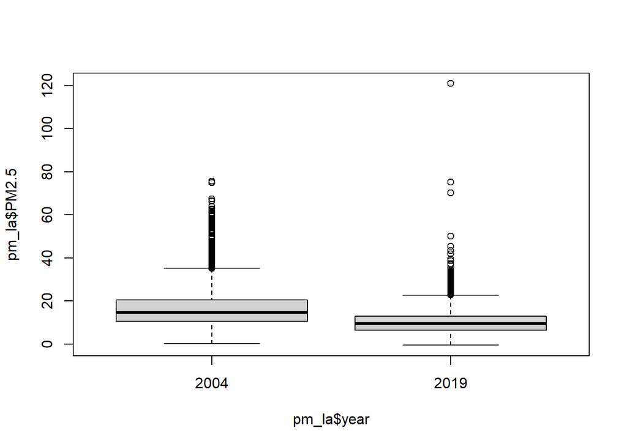

```r
pm_la=pmdata[which(pmdata[,COUNTY]=='Los Angeles')]
boxplot(pm_la$PM2.5~pm_la$year)
```

LA county has the similar result to the whole California. 2004 has a higher PM2.5 value than 2019. But there are some extreme values on some specific days for 2019. Maybe it is because the wildfire or some industrial air pollution.

For the site in Los Angeles-North Main Street

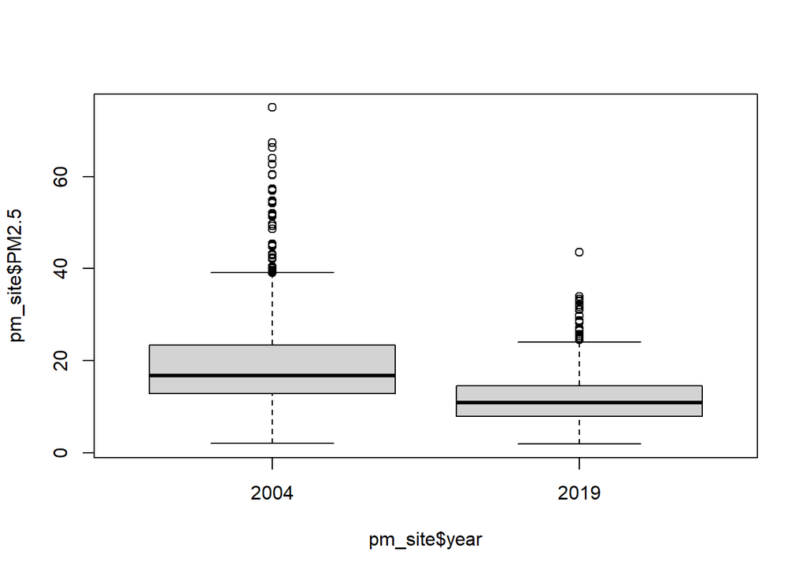

```r
pm_site = pm_la[which(pm_la[,`Site Name`]=='Los Angeles-North Main Street')]
boxplot(pm_site$PM2.5~pm_site$year)
```

The site in Los Angeles-North Main Street has the similar result as well. We can conclude that daily concentrations of PM2.5 has decreased in LA main street from 2004 to 2019.